# Mini Project 1 Analysis

Katelyn Bailey

2025-05-31

```r
library(tidyverse)
```

```r
library(dplyr)
library(ggplot2)
library(lubridate)
library(here)
birth <- read_csv(here("data", "us_births_00_14.csv"))
# check head, missing values, and data structure
head(birth)
```

```
## # A tibble: 6 × 6
##    year month date_of_month date       day_of_week births
##   <dbl> <dbl>         <dbl> <date>     <chr>        <dbl>
## 1  2000     1             1 2000-01-01 Sat           9083
## 2  2000     1             2 2000-01-02 Sun           8006
## 3  2000     1             3 2000-01-03 Mon          11363
## 4  2000     1             4 2000-01-04 Tues         13032
## 5  2000     1             5 2000-01-05 Wed          12558
## 6  2000     1             6 2000-01-06 Thurs        12466
```

```r
sum(is.na(birth))
```

```
## [1] 0
```

```r
str(birth)
```

```
## spc_tbl_ [5,479 × 6] (S3: spec_tbl_df/tbl_df/tbl/data.frame)
##  $ year         : num [1:5479] 2000 2000 2000 2000 2000 2000 2000 2000 2000 2000 ...
##  $ month        : num [1:5479] 1 1 1 1 1 1 1 1 1 1 ...
##  $ date_of_month: num [1:5479] 1 2 3 4 5 6 7 8 9 10 ...
##  $ date         : Date[1:5479], format: "2000-01-01" "2000-01-02" ...
##  $ day_of_week  : chr [1:5479] "Sat" "Sun" "Mon" "Tues" ...
##  $ births       : num [1:5479] 9083 8006 11363 13032 12558 ...
##  - attr(*, "spec")=
##   .. cols(
##   ..   year = col_double(),
##   ..   month = col_double(),
##   ..   date_of_month = col_double(),
##   ..   date = col_date(format = ""),
##   ..   day_of_week = col_character(),
##   ..   births = col_double()
##   .. )
##  - attr(*, "problems")=<externalptr>
```

```r
# most popular birthday every month of every year
birth %>% group_by(year, month) %>% filter(births == max(births))
```

```
## # A tibble: 181 × 6
## # Groups:   year, month [180]
##     year month date_of_month date       day_of_week births
##    <dbl> <dbl>         <dbl> <date>     <chr>        <dbl>
##  1  2000     1             4 2000-01-04 Tues         13032
##  2  2000     2            15 2000-02-15 Tues         13017
##  3  2000     3            14 2000-03-14 Tues         12773
##  4  2000     4            11 2000-04-11 Tues         12850
##  5  2000     5            23 2000-05-23 Tues         13097
##  6  2000     6            29 2000-06-29 Thurs        13462
##  7  2000     7             6 2000-07-06 Thurs        13853
##  8  2000     8             8 2000-08-08 Tues         13693
##  9  2000     9             6 2000-09-06 Wed          13917
## 10  2000    10             5 2000-10-05 Thurs        13288
## # ℹ 171 more rows
```

```r
# most popular birthdays
birth %>% group_by(month, date_of_month) %>% summarise(birthday = sum(births)) %>% arrange(desc(birthday))
```

```
## # A tibble: 366 × 3
## # Groups:   month [12]
##    month date_of_month birthday
##    <dbl>         <dbl>    <dbl>
##  1     9            12   191024
##  2     9            19   190435
##  3     9            20   188123
##  4    12            19   186685
##  5     9            10   186668
##  6    12            20   186593
##  7     9            18   186387
##  8     8             8   186328
##  9     9            26   186322
## 10     9            17   185792
## # ℹ 356 more rows
```

```r
# births by day of week
birth %>% group_by(day_of_week) %>% summarise(total_births_bydw = sum(births)) %>% arrange(desc(total_births_bydw))
```

```
## # A tibble: 7 × 2
##   day_of_week total_births_bydw
##   <chr>                   <dbl>
## 1 Tues                 10274874
## 2 Wed                  10109130
## 3 Thurs                10045436
## 4 Fri                   9850199
## 5 Mon                   9316001
## 6 Sat                   6704495
## 7 Sun                   5886889
```

```r
# births by month
birth %>% group_by(month) %>% summarise(total_births_bym = sum(births)) %>% arrange(desc(total_births_bym))
```

```
## # A tibble: 12 × 2
##    month total_births_bym
##    <dbl>            <dbl>
##  1     8          5540170
##  2     7          5450418
##  3     9          5399592
##  4    10          5302865
##  5     5          5195445
##  6    12          5194432
##  7     3          5172961
##  8     6          5163360
##  9     1          5072588
## 10    11          5008750
## 11     4          4960750
## 12     2          4725693
```

```r
# births by year
birth %>% group_by(year) %>% summarise(total_births_byy = sum(births)) %>% arrange(desc(total_births_byy))
```

```
## # A tibble: 15 × 2
##     year total_births_byy
##    <dbl>            <dbl>
##  1  2007          4380784
##  2  2006          4335154
##  3  2008          4310737
##  4  2005          4211941
##  5  2009          4190991
##  6  2004          4186863
##  7  2003          4163060
##  8  2000          4149598
##  9  2001          4110963
## 10  2002          4099313
## 11  2010          4055975
## 12  2014          4010532
## 13  2011          4006908
## 14  2012          4000868
## 15  2013          3973337
```

> Fun facts: - The day I was born is the most popular birthday in April of 2002! My birthday is also the most popular in April of 2013. - Valentine’s day was the most popular birthday in Feburary of 2001, 2002, 2003, 2006, 2008, 2012, and 2013. - 13/15 of the most popular November birthdays fell between the 20th and the 26th – all on the Tuesday before thanksgiving!! - The most popular day to be born is September 12th. - Valentine’s is the 48th most popular day to be born and the 1st most popular birthday in the first half of the year. - The least number of people are born on leap day, totalling 41869 for this time period. - Tuesday is the most popular day of the week and August is the most popular month.

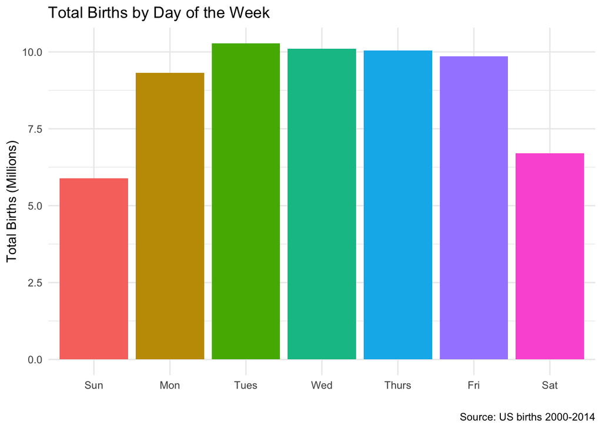

```r
birth %>% group_by(day_of_week) %>% summarise(total_births = sum(births)) %>%
  mutate(day = factor(day_of_week, levels = c("Sun", "Mon", "Tues", "Wed", "Thurs", "Fri", "Sat"))) %>%
  ggplot(aes(x = day, y = total_births/1000000, fill = day)) + geom_col() +
  labs(title = "Total Births by Day of the Week", x = "", y = "Total Births (Millions)", caption = "Source: US births 2000-2014") +
  theme_minimal() + theme(legend.position = "none")
```

```r
ggsave("births_dow.png")
```

> Suday is the least popular day, with Saturday-Monday being less than Tuesday-Friday, and Tuesday being the most popular day.

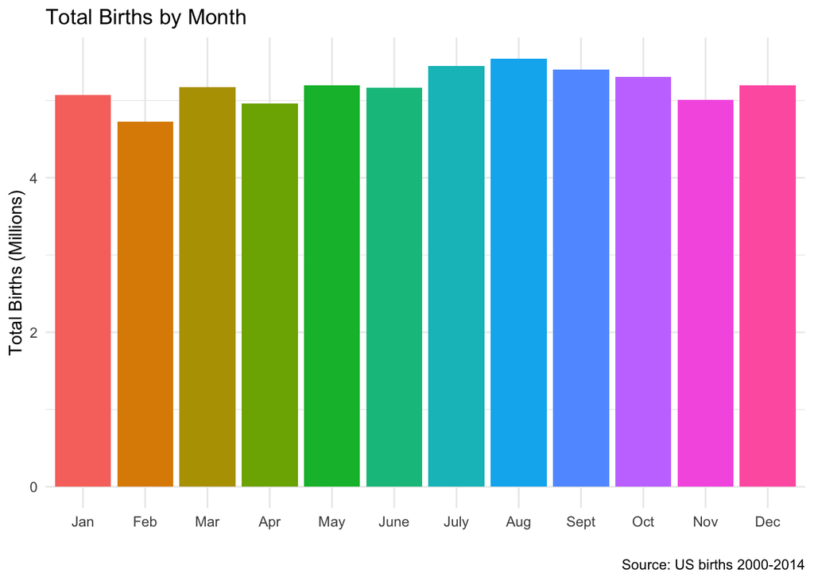

```r
birth %>% group_by(month) %>% summarise(total_births = sum(births)) %>%
  mutate(month = factor(month, levels = 1:12, labels = c("Jan", "Feb", "Mar", "Apr", "May", "June", "July", "Aug", "Sept", "Oct", "Nov", "Dec"))) %>%
  ggplot(aes(x = month, y = total_births/1000000, fill = month)) + geom_col() +
  labs(title = "Total Births by Month", x = "", y = "Total Births (Millions)", caption = "Source: US births 2000-2014") +
  theme_minimal() + theme(legend.position = "none")
```

```r
ggsave("births_month.png")
```

> A decrease in births in early spring and an increase in births in late summer/early fall. Low: Feburary; High: August

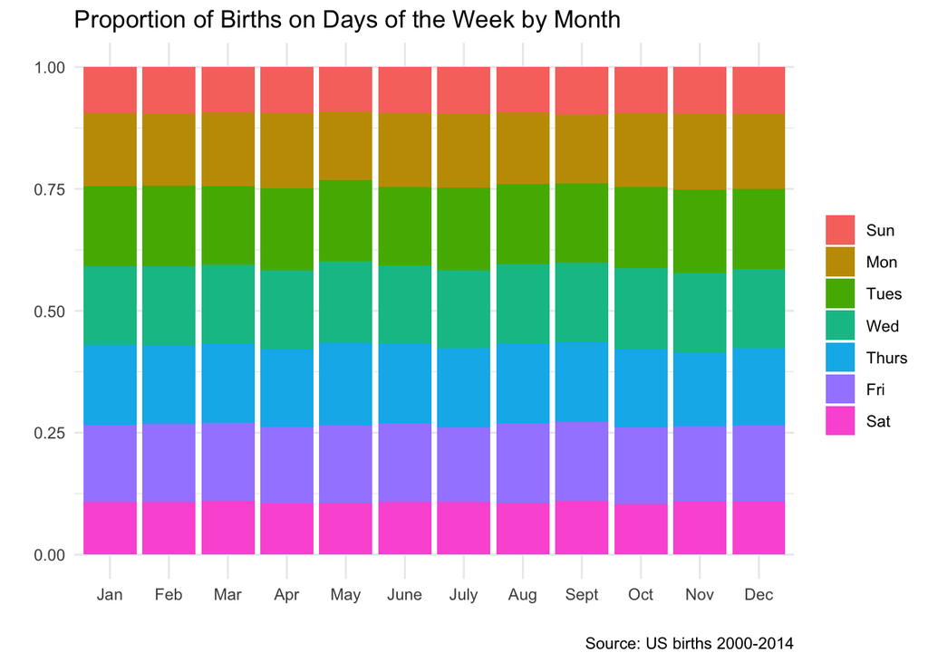

```r
birth %>% group_by(month, day_of_week) %>% summarise(total_births = sum(births)) %>%
  mutate(month = factor(month, levels = 1:12, labels = c("Jan", "Feb", "Mar", "Apr", "May", "June", "July", "Aug", "Sept", "Oct", "Nov", "Dec")),
         day_of_week = factor(day_of_week, levels = c("Sun", "Mon", "Tues", "Wed", "Thurs", "Fri", "Sat"))) %>%
  ggplot(aes(x = month, y = total_births/1000000, fill = day_of_week)) + geom_bar(stat = "identity", position = "fill") +
  labs(title = "Proportion of Births on Days of the Week by Month", y = "", x = "", fill = "", caption = "Source: US births 2000-2014") +
  theme_minimal() + theme(legend.position = "right")
```

```r
ggsave("births_proportion_dow_month.png")
```

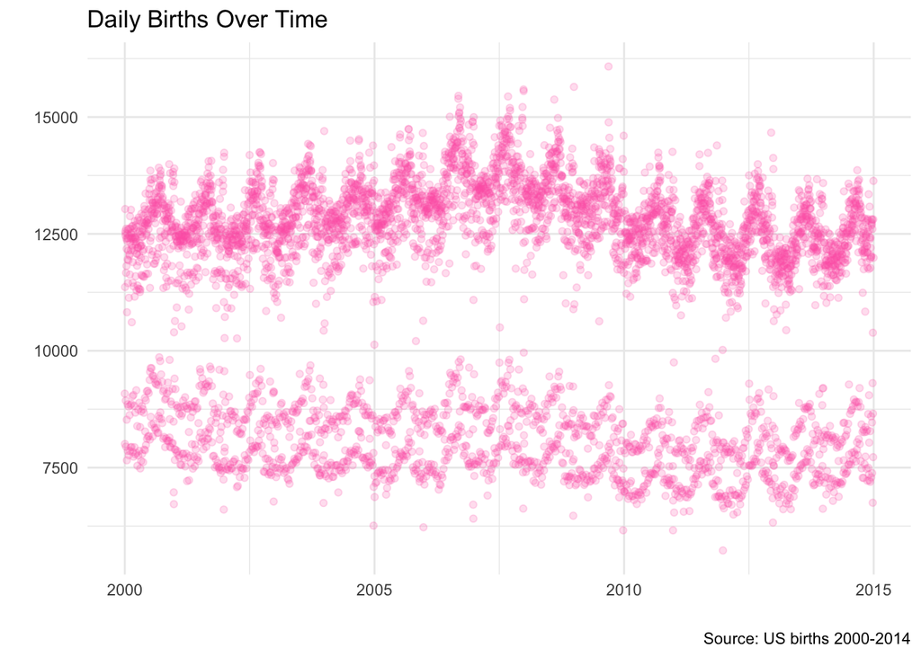

```r
ggplot(birth, aes(x = date, y = births)) +
  geom_point(color = "hotpink", alpha = .2) +
  labs(title = "Daily Births Over Time", x = "", y = "", caption = "Source: US births 2000-2014") +
  theme_minimal()
```

```r
ggsave("births_over_time.png")
```

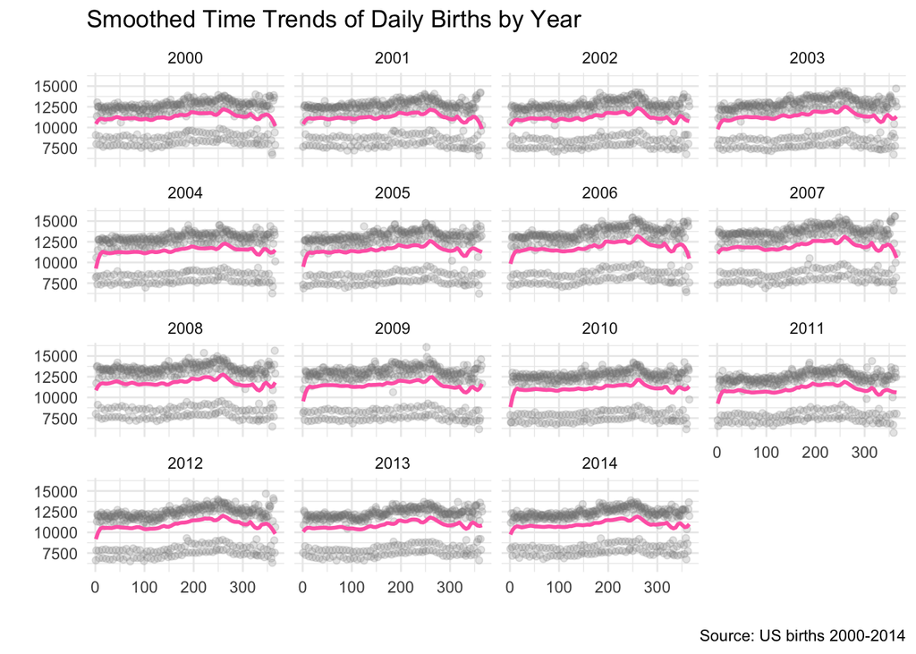

```r
birth %>% mutate(day_of_year = yday(date)) %>% group_by(date, year, day_of_year) %>%
  summarise(total_births = sum(births), .groups = "drop") %>%
  ggplot(aes(x = day_of_year, y = total_births)) + geom_point(alpha = 0.2, color = "gray50") +
  geom_smooth(method = "loess", span = 0.1, color = "hotpink", se = FALSE) +
  facet_wrap(~ year) + labs(title = "Smoothed Time Trends of Daily Births by Year", caption = "Source: US births 2000-2014",
    x = "", y = "") + theme_minimal()
```

```r
ggsave("births_yearly_facets.png")
```

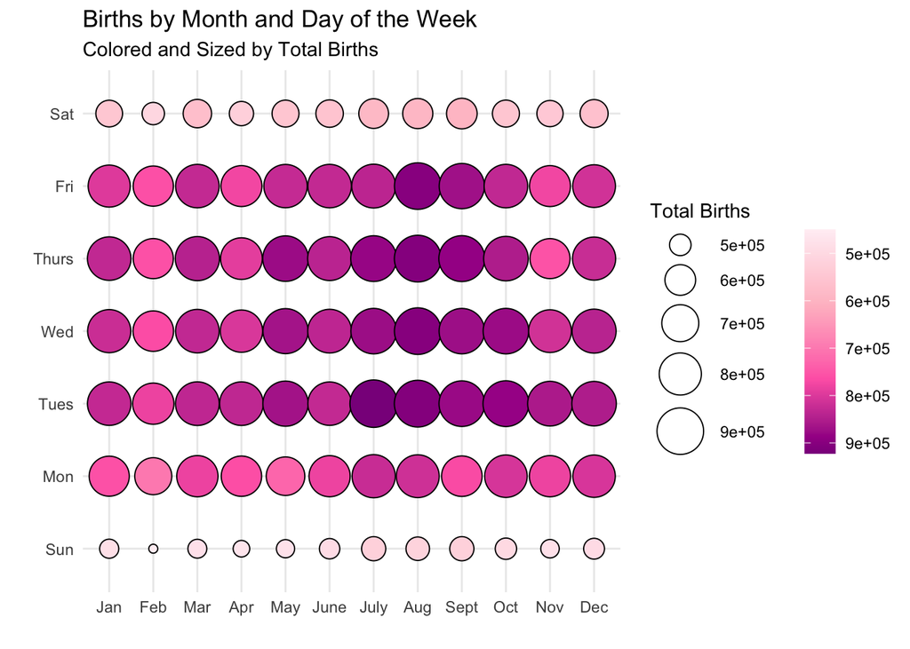

```r
birth %>% group_by(month, day_of_week) %>% summarise(total_births = sum(births), .groups = "drop") %>%
  mutate(month = factor(month, levels = 1:12, labels = c("Jan", "Feb", "Mar", "Apr", "May", "June", "July", "Aug", "Sept", "Oct", "Nov", "Dec")),
         day_of_week = factor(day_of_week, levels = c("Sun", "Mon", "Tues", "Wed", "Thurs", "Fri", "Sat"))) %>%
  ggplot(aes(x = month, y = day_of_week)) +
  geom_point(aes(size = total_births, fill = total_births), shape = 21) +
  scale_size_continuous(range = c(2, 12), name = "Total Births", ) +
  scale_fill_gradientn(colors = c("#fff0f5", "pink", "hotpink", "darkmagenta"), name = "",
                       guide = guide_colorbar(reverse = TRUE,  barheight = unit(125, "pt"))) +
  labs(title = "Births by Month and Day of the Week", subtitle = "Colored and Sized by Total Births", x = "", y = "") +
  theme_minimal() + theme(legend.position = "right", legend.box = "horizontal")
```

```r
ggsave("births_dot_matrix.png")
```

> Least popular month and day combination being Sundays in February and the most favorable combinations being Tuesdays-Thursdays in July-September. By the horizontal patterns, Saturdays and Sundays have considerably less than the weekdays with Mondays following behind them. By the vertical patterns, seasonal patterns with higher births in July to September